# Reproducible Research Course Project 1

Annette Spithoven

10-11-2019

## Introduction

It is now possible to collect a large amount of data about personal movement using activity monitoring devices such as a Fitbit, Nike Fuelband, or Jawbone Up. These type of devices are part of the “quantified self” movement – a group of enthusiasts who take measurements about themselves regularly to improve their health, to find patterns in their behavior, or because they are tech geeks. But these data remain under-utilized both because the raw data are hard to obtain and there is a lack of statistical methods and software for processing and interpreting the data.

The first project assignment for the course Reproductible Research makes use of data from a personal activity monitoring device.

### The Data

Data was collected from an anonymous individual at 5 minute intervals through out the day during the months of October and November, 2012. The data does include the number of steps taken in 5 minute intervals each day.

The variables included in this dataset are:

- steps: Number of steps taking in a 5-minute interval (missing values are coded as NA)
- date: The date on which the measurement was taken in YYYY-MM-DD format
- interval: Identifier for the 5-minute interval in which measurement was taken

## Loading and Preparing the Data

Rather than manually downloading the file from the internet, we use R to download and unzip it. This way, our steps are reproducible (also see Video: Reproducible Reserach Checklist (part 1) of week 3).

```r
## Download the zip file
download.file("https://d396qusza40orc.cloudfront.net/repdata%2Fdata%2Factivity.zip", "repdata%2Fdata%2Factivity.zip")
## unzip it in the working dir so that we can read the csv
unzip("repdata%2Fdata%2Factivity.zip")
## read the data
data <- read.csv("activity.csv") %>%
  mutate(date = as.Date(date))
```

In order to get some insights in the data, an overview of its structure and a summary of the data is provided.

```r
str(data)
```

```
## 'data.frame':    17568 obs. of  3 variables:
##  $ steps   : int  NA NA NA NA NA NA NA NA NA NA ...
##  $ date    : Date, format: "2012-10-01" "2012-10-01" ...
##  $ interval: int  0 5 10 15 20 25 30 35 40 45 ...
```

```r
summary(data)
```

```
##      steps             date               interval
##  Min.   :  0.00   Min.   :2012-10-01   Min.   :   0.0
##  1st Qu.:  0.00   1st Qu.:2012-10-16   1st Qu.: 588.8
##  Median :  0.00   Median :2012-10-31   Median :1177.5
##  Mean   : 37.38   Mean   :2012-10-31   Mean   :1177.5
##  3rd Qu.: 12.00   3rd Qu.:2012-11-15   3rd Qu.:1766.2
##  Max.   :806.00   Max.   :2012-11-30   Max.   :2355.0
##  NA's   :2304
```

```r
head(data, 10)
```

```
##    steps       date interval
## 1     NA 2012-10-01        0
## 2     NA 2012-10-01        5
## 3     NA 2012-10-01       10
## 4     NA 2012-10-01       15
## 5     NA 2012-10-01       20
## 6     NA 2012-10-01       25
## 7     NA 2012-10-01       30
## 8     NA 2012-10-01       35
## 9     NA 2012-10-01       40
## 10    NA 2012-10-01       45
```

## (Research) Questions

### 1. What is mean total number of steps taken per day?

As the data is by interval, the data needs to be aggregated in order to answer a question on daily level. Missing value are ignored.

```r
data_daily <- data %>%
  group_by(date) %>%
  summarise(total_steps = sum(steps, na.rm = TRUE))

head(data_daily, 10)
```

```
## # A tibble: 10 x 2
##    date       total_steps
##    <date>           <int>
##  1 2012-10-01           0
##  2 2012-10-02         126
##  3 2012-10-03       11352
##  4 2012-10-04       12116
##  5 2012-10-05       13294
##  6 2012-10-06       15420
##  7 2012-10-07       11015
##  8 2012-10-08           0
##  9 2012-10-09       12811
## 10 2012-10-10        9900
```

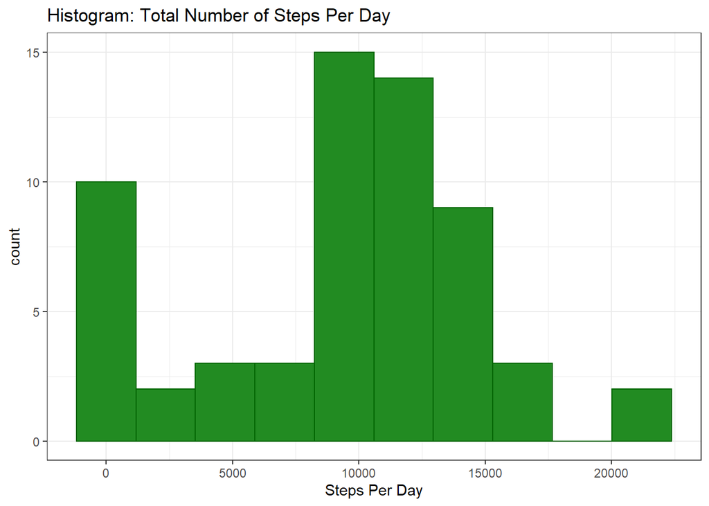

```r
ggplot(data_daily, aes(x = total_steps)) +
  geom_histogram(bins = 10,
                 ## setting colors so that the bars become clear
                 col = "darkgreen",
                 fill = "forestgreen") +
  labs(title = "Histogram: Total Number of Steps Per Day",
       x = "Steps Per Day") +
  theme_bw()
```

#### 1.1 Mean and Median Number of Steps Taken each day

As part of the assignment it was stated to calculated the mean and median, which are given below.

```r
mean(data_daily$total_steps, na.rm = TRUE)
```

```
## [1] 9354.23
```

```r
median(data_daily$total_steps, na.rm = TRUE)
```

```
## [1] 10395
```

### 2. What is the average daily activity pattern?

This question requires the number of steps to be aggreated by interval.

```r
data_interval <- data %>%
  group_by(interval) %>%
  summarise(mean_steps = mean(steps, na.rm = TRUE))

head(data_interval, 10)
```

```
## # A tibble: 10 x 2
##    interval mean_steps
##       <int>      <dbl>
##  1        0     1.72
##  2        5     0.340
##  3       10     0.132
##  4       15     0.151
##  5       20     0.0755
##  6       25     2.09
##  7       30     0.528
##  8       35     0.868
##  9       40     0
## 10       45     1.47
```

In order to see the average pattern of daily activity across intervals, a time series plot is made.

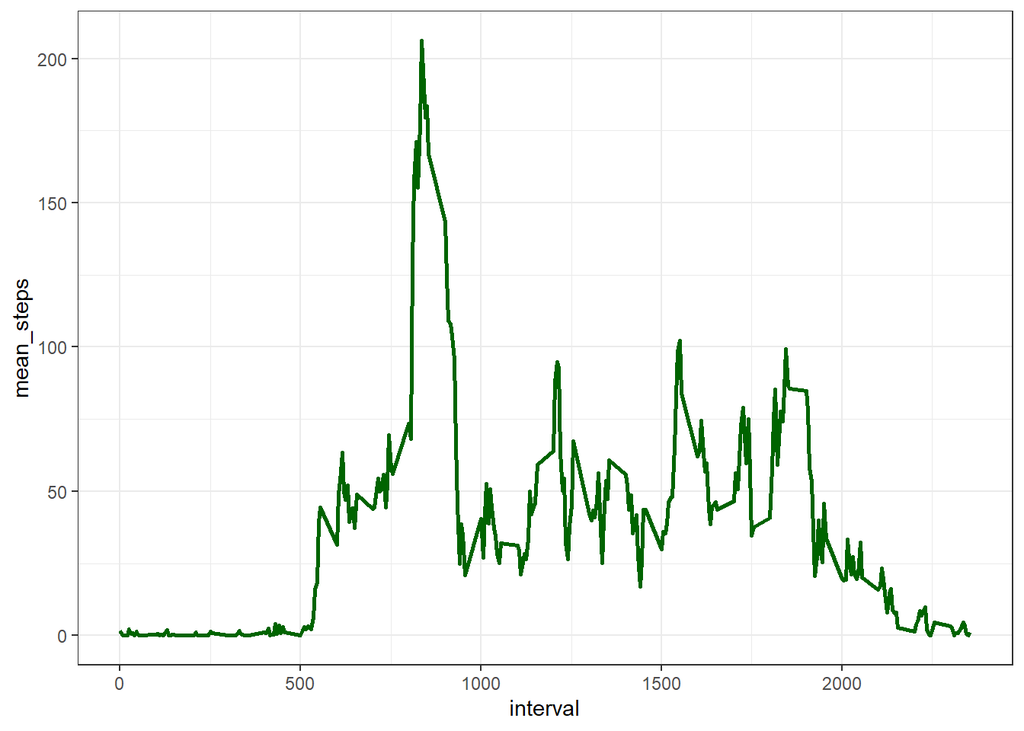

```r
ggplot(data_interval, aes(x = interval, y = mean_steps)) +
  geom_line(size = 1,
            col = "darkgreen")+
  theme_bw()
```

#### Which 5-minute interval contains the maximum number of steps?

```r
data_interval[which(data_interval$mean_steps == max(data_interval$mean_steps, na.rm = TRUE)), 1]
```

```
## # A tibble: 1 x 1
##   interval
##      <int>
## 1      835
```